# Data Visualization Project

## Analysis and Visualization of Loan Data from Prosper

#### By Lovelina Richter

August 2020

The data is provided by Udacity. The data set contains 113,937 loan records with 81 variables on each loan. Variables included in the data set are Loan amount, Borrower rate (or interest rate), Current loan status, Borrower Income, Employment Status, Occupation, and many others. The data dictionary is provided with defintion of each variable. The project requirement is to explore 10 to 15 variables only.

1. Data Dictionary
1. Data Wrangling

   2.1 Data Gathering

   2.2 Data Assessment

   2.3 Data Cleanup
1. Data Vizualization

   3.1 Univariate Exploration

   3.2 Bivariate Exploration

   3.3 Multivariate Exploration
1. Summary
1. References

#### Data Dictionary: Variables to be used in analysis

1. ListingKey: Unique key for each listing, same value as the 'key' used in the listing object in the API.
2. LoanStatus: The current status of the loan: Cancelled, Chargedoff, Completed, Current, Defaulted, FinalPaymentInProgress, PastDue. The PastDue status will be accompanied by a delinquency bucket.
3. BorrowerAPR: The Borrower's Annual Percentage Rate (APR) for the loan.
4. EstimatedReturn: The estimated return assigned to the listing at the time it was created. Estimated return is the difference between the Estimated Effective Yield and the Estimated Loss Rate. Applicable for loans originated after July 2009.
5. ProsperRating (numeric): The Prosper Rating assigned at the time the listing was created: 0 - N/A, 1 - HR, 2 - E, 3 - D, 4 - C, 5 - B, 6 - A, 7 - AA. Applicable for loans originated after July 2009.
6. ListingCategory: The category of the listing that the borrower selected when posting their listing: 0 - Not Available, 1 - Debt Consolidation, 2 - Home Improvement, 3 - Business, 4 - Personal Loan, 5 - Student Use, 6 - Auto, 7- Other, 8 - Baby&Adoption, 9 - Boat, 10 - Cosmetic Procedure, 11 - Engagement Ring, 12 - Green Loans, 13 - Household Expenses, 14 - Large Purchases, 15 - Medical/Dental, 16 - Motorcycle, 17 - RV, 18 - Taxes, 19 - Vacation, 20 - Wedding Loans
7. BorrowerState: The two letter abbreviation of the state of the address of the borrower at the time the Listing was created.
8. Occupation: The Occupation selected by the Borrower at the time they created the listing.
9. EmploymentStatus: The employment status of the borrower at the time they posted the listing.
10. IsBorrowerHomeowner: A Borrower will be classified as a homowner if they have a mortgage on their credit profile or provide documentation confirming they are a homeowner.
11. CreditScoreRangeUpper: The upper value representing the range of the borrower's credit score as provided by a consumer credit rating agency.
12. CurrentCreditLine:s Number of current credit lines at the time the credit profile was pulled.
13. IncomeRange: The income range of the borrower at the time the listing was created.
14. IncomeVerifiable: The borrower indicated they have the required documentation to support their income.
15. LoanOriginalAmount: The origination amount of the loan.

```python
# import all packages and set plots to be embedded inline
import numpy as np
import pandas as pd
import matplotlib.pyplot as plt
import seaborn as sb

%matplotlib inline

# Ignore warning messages
import warnings
warnings.filterwarnings('ignore')
```

### Data Wrangling

#### Data Gathering

Read CSV file

```python
# read data and save to panda dataframe
df = pd.read_csv('prosperLoanData.csv')
```

#### Data Assessment

##### Inspect Data Structure

```python
#view the dataframe dimensions, shows the number of records and columns
df.shape
```

```
(113937, 81)
```

```python
#View the data from top rows of the frame
df.head()
```

|  | ListingKey | ListingNumber | ListingCreationDate | CreditGrade | Term | LoanStatus | ClosedDate | BorrowerAPR | BorrowerRate | LenderYield | ... | LP_ServiceFees | LP_CollectionFees | LP_GrossPrincipalLoss | LP_NetPrincipalLoss | LP_NonPrincipalRecoverypayments | PercentFunded | Recommendations | InvestmentFromFriendsCount | InvestmentFromFriendsAmount | Investors |
| --- | --- | --- | --- | --- | --- | --- | --- | --- | --- | --- | --- | --- | --- | --- | --- | --- | --- | --- | --- | --- | --- |
| 0 | 1021339766868145413AB3B | 193129 | 2007-08-26 19:09:29.263000000 | C | 36 | Completed | 2009-08-14 00:00:00 | 0.16516 | 0.1580 | 0.1380 | ... | -133.18 | 0.0 | 0.0 | 0.0 | 0.0 | 1.0 | 0 | 0 | 0.0 | 258 |
| 1 | 10273602499503308B223C1 | 1209647 | 2014-02-27 08:28:07.900000000 | NaN | 36 | Current | NaN | 0.12016 | 0.0920 | 0.0820 | ... | 0.00 | 0.0 | 0.0 | 0.0 | 0.0 | 1.0 | 0 | 0 | 0.0 | 1 |
| 2 | 0EE9337825851032864889A | 81716 | 2007-01-05 15:00:47.090000000 | HR | 36 | Completed | 2009-12-17 00:00:00 | 0.28269 | 0.2750 | 0.2400 | ... | -24.20 | 0.0 | 0.0 | 0.0 | 0.0 | 1.0 | 0 | 0 | 0.0 | 41 |
| 3 | 0EF5356002482715299901A | 658116 | 2012-10-22 11:02:35.010000000 | NaN | 36 | Current | NaN | 0.12528 | 0.0974 | 0.0874 | ... | -108.01 | 0.0 | 0.0 | 0.0 | 0.0 | 1.0 | 0 | 0 | 0.0 | 158 |
| 4 | 0F023589499656230C5E3E2 | 909464 | 2013-09-14 18:38:39.097000000 | NaN | 36 | Current | NaN | 0.24614 | 0.2085 | 0.1985 | ... | -60.27 | 0.0 | 0.0 | 0.0 | 0.0 | 1.0 | 0 | 0 | 0.0 | 20 |

5 rows × 81 columns

```python
#This shows information about a DataFrame including the index dtype and column dtypes, non-null values and memory usage.
df.info()
```

```
<class 'pandas.core.frame.DataFrame'>
RangeIndex: 113937 entries, 0 to 113936
Data columns (total 81 columns):
 #   Column                               Non-Null Count   Dtype
---  ------                               --------------   -----
 0   ListingKey                           113937 non-null  object
 1   ListingNumber                        113937 non-null  int64
 2   ListingCreationDate                  113937 non-null  object
 3   CreditGrade                          28953 non-null   object
 4   Term                                 113937 non-null  int64
 5   LoanStatus                           113937 non-null  object
 6   ClosedDate                           55089 non-null   object
 7   BorrowerAPR                          113912 non-null  float64
 8   BorrowerRate                         113937 non-null  float64
 9   LenderYield                          113937 non-null  float64
```

[output cut: 73 more lines]

```python
# Quick analysis of some of the numbers, view the dataframe descriptive statistics
df.describe()
```

|  | ListingNumber | Term | BorrowerAPR | BorrowerRate | LenderYield | EstimatedEffectiveYield | EstimatedLoss | EstimatedReturn | ProsperRating (numeric) | ProsperScore | ... | LP_ServiceFees | LP_CollectionFees | LP_GrossPrincipalLoss | LP_NetPrincipalLoss | LP_NonPrincipalRecoverypayments | PercentFunded | Recommendations | InvestmentFromFriendsCount | InvestmentFromFriendsAmount | Investors |
| --- | --- | --- | --- | --- | --- | --- | --- | --- | --- | --- | --- | --- | --- | --- | --- | --- | --- | --- | --- | --- | --- |
| count | 1.139370e+05 | 113937.000000 | 113912.000000 | 113937.000000 | 113937.000000 | 84853.000000 | 84853.000000 | 84853.000000 | 84853.000000 | 84853.000000 | ... | 113937.000000 | 113937.000000 | 113937.000000 | 113937.000000 | 113937.000000 | 113937.000000 | 113937.000000 | 113937.000000 | 113937.000000 | 113937.000000 |
| mean | 6.278857e+05 | 40.830248 | 0.218828 | 0.192764 | 0.182701 | 0.168661 | 0.080306 | 0.096068 | 4.072243 | 5.950067 | ... | -54.725641 | -14.242698 | 700.446342 | 681.420499 | 25.142686 | 0.998584 | 0.048027 | 0.023460 | 16.550751 | 80.475228 |
| std | 3.280762e+05 | 10.436212 | 0.080364 | 0.074818 | 0.074516 | 0.068467 | 0.046764 | 0.030403 | 1.673227 | 2.376501 | ... | 60.675425 | 109.232758 | 2388.513831 | 2357.167068 | 275.657937 | 0.017919 | 0.332353 | 0.232412 | 294.545422 | 103.239020 |
| min | 4.000000e+00 | 12.000000 | 0.006530 | 0.000000 | -0.010000 | -0.182700 | 0.004900 | -0.182700 | 1.000000 | 1.000000 | ... | -664.870000 | -9274.750000 | -94.200000 | -954.550000 | 0.000000 | 0.700000 | 0.000000 | 0.000000 | 0.000000 | 1.000000 |
| 25% | 4.009190e+05 | 36.000000 | 0.156290 | 0.134000 | 0.124200 | 0.115670 | 0.042400 | 0.074080 | 3.000000 | 4.000000 | ... | -73.180000 | 0.000000 | 0.000000 | 0.000000 | 0.000000 | 1.000000 | 0.000000 | 0.000000 | 0.000000 | 2.000000 |
| 50% | 6.005540e+05 | 36.000000 | 0.209760 | 0.184000 | 0.173000 | 0.161500 | 0.072400 | 0.091700 | 4.000000 | 6.000000 | ... | -34.440000 | 0.000000 | 0.000000 | 0.000000 | 0.000000 | 1.000000 | 0.000000 | 0.000000 | 0.000000 | 44.000000 |
| 75% | 8.926340e+05 | 36.000000 | 0.283810 | 0.250000 | 0.240000 | 0.224300 | 0.112000 | 0.116600 | 5.000000 | 8.000000 | ... | -13.920000 | 0.000000 | 0.000000 | 0.000000 | 0.000000 | 1.000000 | 0.000000 | 0.000000 | 0.000000 | 115.000000 |
| max | 1.255725e+06 | 60.000000 | 0.512290 | 0.497500 | 0.492500 | 0.319900 | 0.366000 | 0.283700 | 7.000000 | 11.000000 | ... | 32.060000 | 0.000000 | 25000.000000 | 25000.000000 | 21117.900000 | 1.012500 | 39.000000 | 33.000000 | 25000.000000 | 1189.000000 |

8 rows × 61 columns

#### Data Cleanup

```python
# copy original datasets
clean_df = df.copy()
```

```python
#Remove duplicate Listing Key
clean_df = clean_df.sort_values('ListingKey').drop_duplicates('ListingKey', keep ='last')
```

```python
#Rename columns with spaces, for easier coding
clean_df = clean_df.rename(columns = {'ProsperRating (numeric)':'ProsperRatingN',
                                      'ListingCategory (numeric)': 'ListingCategoryN'})
```

```python
#Check how many duplicates were removed
#original count = 113,937
clean_df.shape
```

```
(113066, 81)
```

```python
#drop columns that i am not interest to analyze, for easy reading and cleaner data structure
clean_df = clean_df.drop(['ListingNumber','ListingCreationDate','CreditGrade','Term','ClosedDate','BorrowerRate','LenderYield','EstimatedEffectiveYield','EstimatedLoss','ProsperRating (Alpha)','ProsperScore','CurrentlyInGroup','GroupKey','DateCreditPulled','CreditScoreRangeLower','FirstRecordedCreditLine','OpenCreditLines','TotalCreditLinespast7years','OpenRevolvingAccounts','OpenRevolvingMonthlyPayment','InquiriesLast6Months','TotalInquiries','CurrentDelinquencies','AmountDelinquent','DelinquenciesLast7Years','PublicRecordsLast10Years','PublicRecordsLast12Months','RevolvingCreditBalance','BankcardUtilization','AvailableBankcardCredit','TotalTrades','TradesNeverDelinquent (percentage)','TradesOpenedLast6Months','StatedMonthlyIncome','LoanKey','TotalProsperLoans','TotalProsperPaymentsBilled','OnTimeProsperPayments','ProsperPaymentsLessThanOneMonthLate','ProsperPaymentsOneMonthPlusLate','ProsperPrincipalBorrowed','ProsperPrincipalOutstanding','ScorexChangeAtTimeOfListing','LoanCurrentDaysDelinquent','LoanFirstDefaultedCycleNumber','LoanMonthsSinceOrigination','LoanNumber','LoanOriginationDate','LoanOriginationQuarter','MemberKey','MonthlyLoanPayment','LP_CustomerPayments','LP_CustomerPrincipalPayments','LP_InterestandFees','LP_ServiceFees','LP_CollectionFees','LP_GrossPrincipalLoss','LP_NetPrincipalLoss','LP_NonPrincipalRecoverypayments','PercentFunded','Recommendations','InvestmentFromFriendsCount','InvestmentFromFriendsAmount','Investors'],axis=1)
```

```python
#Check if columns were removed
clean_df.info()
```

```
<class 'pandas.core.frame.DataFrame'>
Int64Index: 113066 entries, 17277 to 96976
Data columns (total 17 columns):
 #   Column                    Non-Null Count   Dtype
---  ------                    --------------   -----
 0   ListingKey                113066 non-null  object
 1   LoanStatus                113066 non-null  object
 2   BorrowerAPR               113041 non-null  float64
 3   EstimatedReturn           83982 non-null   float64
 4   ProsperRatingN            83982 non-null   float64
 5   ListingCategoryN          113066 non-null  int64
 6   BorrowerState             107551 non-null  object
 7   Occupation                109537 non-null  object
 8   EmploymentStatus          110811 non-null  object
 9   EmploymentStatusDuration  105441 non-null  float64
 10  IsBorrowerHomeowner       113066 non-null  bool
 11  CreditScoreRangeUpper     112475 non-null  float64
 12  CurrentCreditLines        105462 non-null  float64
 13  DebtToIncomeRatio         104594 non-null  float64
 14  IncomeRange               113066 non-null  object
 15  IncomeVerifiable          113066 non-null  bool
 16  LoanOriginalAmount        113066 non-null  int64
dtypes: bool(2), float64(7), int64(2), object(6)
memory usage: 14.0+ MB
```

```python
# Check unique LoanStatus
clean_df['LoanStatus'].unique()
```

```
array(['Defaulted', 'Chargedoff', 'Current', 'Completed',
       'Past Due (61-90 days)', 'Past Due (1-15 days)',
       'FinalPaymentInProgress', 'Past Due (31-60 days)',
       'Past Due (91-120 days)', 'Past Due (16-30 days)', 'Cancelled',
       'Past Due (>120 days)'], dtype=object)
```

```python
# Check unique Employment Status
clean_df['EmploymentStatus'].unique()
```

```
array(['Employed', 'Full-time', nan, 'Self-employed', 'Not employed',
       'Not available', 'Part-time', 'Other', 'Retired'], dtype=object)
```

```python
# Fill nan values with 'Not available'
clean_df['EmploymentStatus'].fillna(value='Not available', inplace=True)
```

```python
# Define EmploymentStatus as a category
employment_status_dict = ['Not available', 'Other', 'Not employed', 'Self-employed',
                                               'Part-time', 'Full-time', 'Employed', 'Retired']

ordered_employment_status = pd.api.types.CategoricalDtype(ordered = True, categories = employment_status_dict)
clean_df['EmploymentStatus'] = clean_df['EmploymentStatus'].astype(ordered_employment_status)
```

```python
# Decode ListingCategory (numeric) feature
list_dict = {0 : 'Not Available', 1 : 'Debt Consolidation', 2 : 'Home Improvement', 3: 'Business',
             4 : 'Personal Loan', 5 : 'Student Use', 6 : 'Auto', 7 : 'Other', 8 : 'Baby&Adoption',
             9 : 'Boat', 10 : 'Cosmetic Procedure', 11 : 'Engagement Ring', 12 : 'Green Loans',
             13 : 'Household Expenses', 14 : 'Large Purchases', 15 : 'Medical/Dental', 16 : 'Motorcycle',
             17 : 'RV', 18 : 'Taxes', 19 : 'Vacation', 20 : 'Wedding Loans'}

clean_df['ListingCategory'] = clean_df['ListingCategoryN'].map(list_dict)
```

```python
# Look at the new ListingCategory feature
clean_df[['ListingCategoryN', 'ListingCategory']].sample(10)
```

|  | ListingCategoryN | ListingCategory |
| --- | --- | --- |
| 93198 | 1 | Debt Consolidation |
| 109103 | 0 | Not Available |
| 25439 | 0 | Not Available |
| 31876 | 0 | Not Available |
| 65247 | 7 | Other |
| 13456 | 1 | Debt Consolidation |
| 39468 | 15 | Medical/Dental |
| 66259 | 1 | Debt Consolidation |
| 9206 | 1 | Debt Consolidation |
| 5382 | 5 | Student Use |

## Data Visualization

### Structure of the dataset

There are 113,937 loan records from Prospect. There are 81 variables in the dataset. Variables included Loan Status, Borrower's APR, Borrower's Interest Rate for the specific loan. Prosper's rating at the time of listing was created.

### Questions to investigate or main interest in the dataset

I am most interested in figuring out What factors affect the loan status? Does Borrower's profile is sole determining factor of the loan status? How many investors are interested in the loan?

### Variables that could help in analysis of data

I expect that the variables related to the following data will help me analyze and figure out the factors that affects status.

1. Prospect's data
2. Borrowers's data
3. Investor's data

## Univariate Exploration

Start by looking at the distribution of each variable of interest

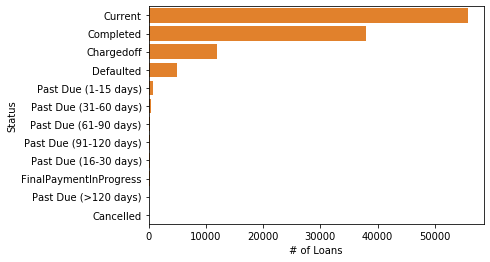

```python
#check percentage of loan status
pct_loans_by_status = pd.DataFrame(clean_df.groupby('LoanStatus')['LoanStatus'].count())
pct_loans_by_status['PercentStatus'] = (pct_loans_by_status['LoanStatus']/pct_loans_by_status['LoanStatus'].sum())*100
pct_loans_by_status.sort_values(by='PercentStatus', ascending=False)

# Plot LoanStatus
default_color = sb.color_palette()[1]

# Order the categorical variable type
cat_order = clean_df['LoanStatus'].value_counts().index

sb.countplot(data = clean_df, y = 'LoanStatus', color = default_color, order=cat_order)
plt.xlabel('# of Loans')
plt.ylabel('Status');
```

```python
# Cleanup Status and save all Past Due loans under an unique value
clean_df['LoanStatus'] = clean_df['LoanStatus'].apply(lambda x: x if 'Past Due' not in x else 'Past Due')

# Convert LoanStatus to a categorical variable
loan_status_dict = ['Defaulted','Chargedoff', 'Past Due', 'Current', 'FinalPaymentInProgress', 'Completed']

ordered_loan_status = pd.api.types.CategoricalDtype(ordered = True, categories = loan_status_dict)

clean_df['LoanStatus'] = clean_df['LoanStatus'].astype(ordered_loan_status)
```

```python
#check percentage of loan status
pct_loans_by_status = pd.DataFrame(clean_df.groupby('LoanStatus')['LoanStatus'].count())
pct_loans_by_status['PercentStatus'] = (pct_loans_by_status['LoanStatus']/pct_loans_by_status['LoanStatus'].sum())*100
pct_loans_by_status.sort_values(by='PercentStatus', ascending=False)
```

| LoanStatus | LoanStatus | PercentStatus |
| --- | --- | --- |
| Current | 55730 | 49.291975 |
| Completed | 38061 | 33.664128 |
| Chargedoff | 11992 | 10.606664 |
| Defaulted | 5018 | 4.438312 |
| Past Due | 2057 | 1.819372 |
| FinalPaymentInProgress | 203 | 0.179549 |

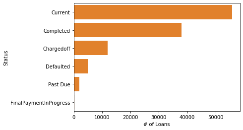

```python
# Plot LoanStatus
default_color = sb.color_palette()[1]

# Order the categorical variable type
cat_order = clean_df['LoanStatus'].value_counts().index

sb.countplot(data = clean_df, y = 'LoanStatus', color = default_color, order=cat_order)
plt.xlabel('# of Loans')
plt.ylabel('Status');
```

About 80% of loan status are current and completed. While 20% are Chargedoff, defaulted, or past due. This will be the main variable of interest, what factors contributed to 80% and 20% distribution?

Next variable to analyze is Loan Original Amount:

```python
#check percentage of loan original amount
pct_loans_by_amount = pd.DataFrame(clean_df.groupby('LoanOriginalAmount')['LoanOriginalAmount'].count())
pct_loans_by_amount['PercentAmount'] = (pct_loans_by_amount['LoanOriginalAmount']/pct_loans_by_amount['LoanOriginalAmount'].sum())*100
pct_loans_by_amount.sort_values(by='PercentAmount', ascending=False)
```

| LoanOriginalAmount | LoanOriginalAmount | PercentAmount |
| --- | --- | --- |
| 4000 | 14207 | 12.565227 |
| 15000 | 12232 | 10.818460 |
| 10000 | 10956 | 9.689916 |
| 5000 | 6953 | 6.149506 |
| 2000 | 6042 | 5.343782 |
| ... | ... | ... |
| 6063 | 1 | 0.000884 |
| 6058 | 1 | 0.000884 |
| 6040 | 1 | 0.000884 |
| 6004 | 1 | 0.000884 |
| 7862 | 1 | 0.000884 |

2468 rows × 2 columns

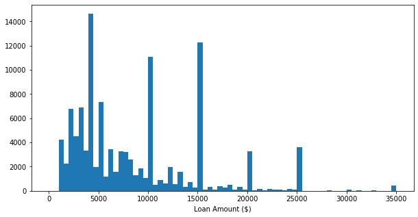

```python
# show loan original amounnt in a chart
binsize = 500
bins = np.arange(0, clean_df['LoanOriginalAmount'].max()+binsize, binsize)

plt.figure(figsize=[10, 5])
plt.hist(data = clean_df, x = 'LoanOriginalAmount', bins = bins)
plt.xlabel('Loan Amount ($)')
plt.show()
```

The distribution of loan amount is quite interesting because it is not distributed normally:

23% are between 2,000 and 5,000

21% are between 10,000 to 15,000

The rest are distributed between 2,000 and 35,000

While the most number of loan is 4,000

Next, is to check how Prosper Rating is distributed:

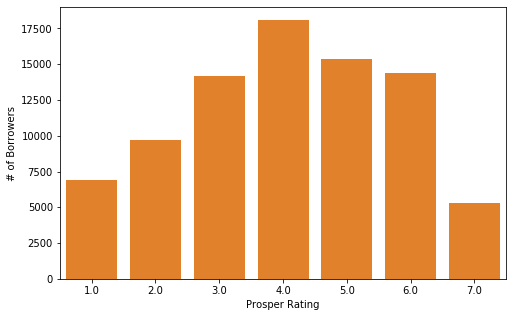

```python
# Plot for Prosper Rating
binsize = 1
bins = np.arange(0, clean_df['ProsperRatingN'].max()+binsize, binsize)

plt.figure(figsize=[8, 5])
sb.countplot(data = clean_df, x = 'ProsperRatingN', color = default_color)
plt.xlabel('Prosper Rating')
plt.ylabel('# of Borrowers');
```

The Prosper Rating assigned at the time the listing was created as follows: 0 - N/A, 1 - HR, 2 - E, 3 - D, 4 - C, 5 - B, 6 - A, 7 - AA. Applicable for loans originated after July 2009.

The Prosper Rating is shows a normal distribution.

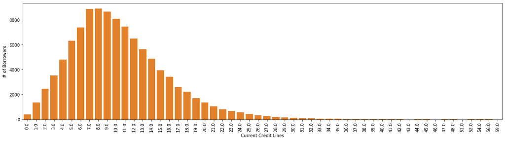

```python
# plot for CurrentCreditLines
plt.subplots(figsize = [20,5])

sb.countplot(data = clean_df, x = 'CurrentCreditLines', color = default_color)
plt.xlabel('Current Credit Lines')
plt.ylabel('# of Borrowers')
plt.xticks(rotation=90);
```

There is a strong distribution of Current Credit lines between 4 and 14, and a long tail for credit line over 15.  
Let's see what is the percentage of credit lines.

```python
#check percentage of Current Credit lines
pct_loans_by_credit = pd.DataFrame(clean_df.groupby('CurrentCreditLines')['CurrentCreditLines'].count())
pct_loans_by_credit['PercentCredit'] = (pct_loans_by_credit['CurrentCreditLines']/pct_loans_by_credit['CurrentCreditLines'].sum())*100
pct_loans_by_credit.sort_values(by='PercentCredit', ascending=False)
```

| CurrentCreditLines | CurrentCreditLines | PercentCredit |
| --- | --- | --- |
| 8.0 | 8908 | 8.446644 |
| 7.0 | 8857 | 8.398286 |
| 9.0 | 8659 | 8.210540 |
| 10.0 | 8068 | 7.650149 |
| 11.0 | 7437 | 7.051829 |
| 6.0 | 7400 | 7.016745 |
| 12.0 | 6473 | 6.137756 |
| 5.0 | 6330 | 6.002162 |
| 13.0 | 5632 | 5.340312 |
| 14.0 | 4883 | 4.630104 |
| 4.0 | 4787 | 4.539076 |
| 15.0 | 3940 | 3.735943 |
| 3.0 | 3540 | 3.356659 |
| 16.0 | 3423 | 3.245719 |
| 17.0 | 2596 | 2.461550 |
| 2.0 | 2464 | 2.336387 |
| 18.0 | 2220 | 2.105024 |
| 19.0 | 1713 | 1.624282 |
| 20.0 | 1366 | 1.295253 |
| 1.0 | 1351 | 1.281030 |
| 21.0 | 1057 | 1.002257 |
| 22.0 | 822 | 0.779428 |
| 23.0 | 658 | 0.623921 |
| 24.0 | 555 | 0.526256 |
| 25.0 | 439 | 0.416264 |
| 0.0 | 385 | 0.365060 |
| 26.0 | 345 | 0.327132 |
| 27.0 | 249 | 0.236104 |
| 28.0 | 202 | 0.191538 |
| 29.0 | 143 | 0.135594 |
| 30.0 | 118 | 0.111889 |
| 31.0 | 89 | 0.084391 |
| 32.0 | 75 | 0.071116 |
| 33.0 | 61 | 0.057841 |
| 34.0 | 39 | 0.036980 |
| 35.0 | 39 | 0.036980 |
| 36.0 | 34 | 0.032239 |
| 37.0 | 23 | 0.021809 |
| 38.0 | 23 | 0.021809 |
| 39.0 | 13 | 0.012327 |
| 40.0 | 10 | 0.009482 |
| 41.0 | 8 | 0.007586 |
| 44.0 | 4 | 0.003793 |
| 42.0 | 3 | 0.002845 |
| 45.0 | 3 | 0.002845 |
| 47.0 | 3 | 0.002845 |
| 48.0 | 3 | 0.002845 |
| 52.0 | 3 | 0.002845 |
| 54.0 | 3 | 0.002845 |
| 56.0 | 2 | 0.001896 |
| 43.0 | 1 | 0.000948 |
| 46.0 | 1 | 0.000948 |
| 51.0 | 1 | 0.000948 |
| 59.0 | 1 | 0.000948 |

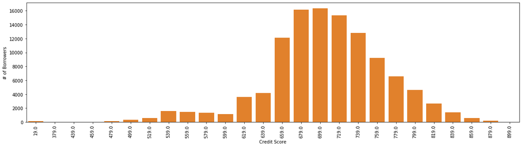

```python
# Plot a standard-scaled plot for CurrentCreditScore
plt.subplots(figsize = [20,5])

sb.countplot(data = clean_df, x = 'CreditScoreRangeUpper', color = default_color)
plt.xlabel('Credit Score')
plt.ylabel('# of Borrowers')
plt.xticks(rotation=90);
```

Interesting distribution of credit score. Average credit score is between 659 and 739. The rest are distributed either low or high credit score. Let us what the percentage of each score.

```python
#check percentage of Current Credit Score
pct_loans_by_creditscore = pd.DataFrame(clean_df.groupby('CreditScoreRangeUpper')['CreditScoreRangeUpper'].count())
pct_loans_by_creditscore['PercentCreditScore'] = (pct_loans_by_creditscore['CreditScoreRangeUpper']/pct_loans_by_creditscore['CreditScoreRangeUpper'].sum())*100
pct_loans_by_creditscore.sort_values(by='PercentCreditScore', ascending=False)
```

| CreditScoreRangeUpper | CreditScoreRangeUpper | PercentCreditScore |
| --- | --- | --- |
| 699.0 | 16315 | 14.505446 |
| 679.0 | 16177 | 14.382752 |
| 719.0 | 15315 | 13.616359 |
| 739.0 | 12797 | 11.377639 |
| 659.0 | 12099 | 10.757057 |
| 759.0 | 9211 | 8.189375 |
| 779.0 | 6566 | 5.837742 |
| 799.0 | 4607 | 4.096021 |
| 639.0 | 4172 | 3.709269 |
| 619.0 | 3601 | 3.201600 |
| 819.0 | 2636 | 2.343632 |
| 539.0 | 1593 | 1.416315 |
| 559.0 | 1474 | 1.310513 |
| 839.0 | 1408 | 1.251834 |
| 579.0 | 1357 | 1.206490 |
| 599.0 | 1125 | 1.000222 |
| 859.0 | 567 | 0.504112 |
| 519.0 | 554 | 0.492554 |
| 499.0 | 346 | 0.307624 |
| 879.0 | 212 | 0.188486 |
| 479.0 | 141 | 0.125361 |
| 19.0 | 133 | 0.118248 |
| 459.0 | 36 | 0.032007 |
| 899.0 | 27 | 0.024005 |
| 439.0 | 5 | 0.004445 |
| 379.0 | 1 | 0.000889 |

Credit score between 659 and 738 is about 65% and the rest are 35% which are distributed either high or low credit score.

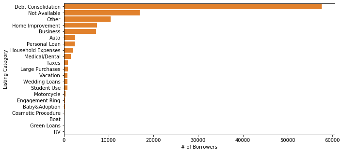

```python
# Plot a standard-scaled plot for ListingCategory
plt.figure(figsize=[10, 5])

# Order the categorical variable type
cat_order = clean_df['ListingCategory'].value_counts().index

sb.countplot(data = clean_df, y = 'ListingCategory', color = default_color, order=cat_order)
plt.ylabel('Listing Category')
plt.xlabel('# of Borrowers');
```

Listing Category which borrower selected are mostly Debt Consolidation.

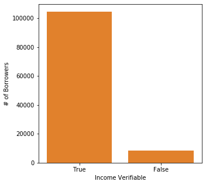

```python
# Plot for IncomeVerifiable
plt.figure(figsize=[5, 5])

# Order the categorical variable type
cat_order = clean_df['IncomeVerifiable'].value_counts().index

sb.countplot(data = clean_df, x = 'IncomeVerifiable', color = default_color, order=cat_order)
plt.xlabel('Income Verifiable')
plt.ylabel('# of Borrowers');
```

Majority of borrowers indicated that their income is verifiable or has supporting document to prove their capacity to pay.

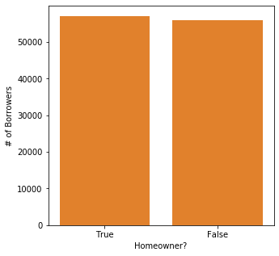

```python
# Plot for IsBorrowerHomeowner
plt.figure(figsize=[5, 5])

# Order the categorical variable type
cat_order = clean_df['IsBorrowerHomeowner'].value_counts().index

sb.countplot(data = clean_df, x = 'IsBorrowerHomeowner', color = default_color, order=cat_order)
plt.xlabel('Homeowner?')
plt.ylabel('# of Borrowers');
```

The Borrower's home ownership will not provide a strong indication to the status of loan because it is distributed evenly.

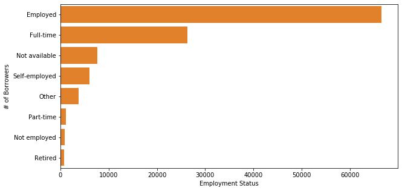

```python
# Plot for EmploymentStatus
plt.figure(figsize=[10, 5])

# Order the categorical variable type
cat_order = clean_df['EmploymentStatus'].value_counts().index

sb.countplot(data = clean_df, y = 'EmploymentStatus', color = default_color, order=cat_order)
plt.xlabel('Employment Status')
plt.ylabel('# of Borrowers');
```

Most borrowers are full-time and employee

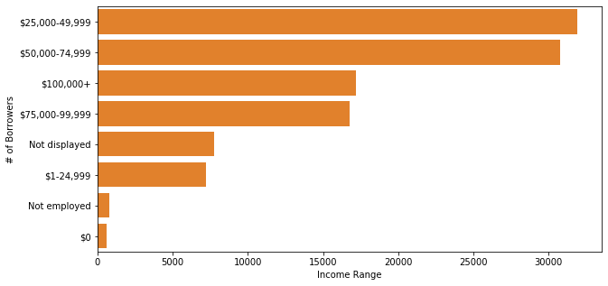

```python
# Plot for Income Range
plt.figure(figsize=[10, 5])

# Order the categorical variable type
cat_order = clean_df['IncomeRange'].value_counts().index

sb.countplot(data = clean_df, y = 'IncomeRange', color = default_color, order=cat_order)
plt.xlabel('Income Range')
plt.ylabel('# of Borrowers');
```

```python
#check percentage of Income Range
pct_loans_by_income = pd.DataFrame(clean_df.groupby('IncomeRange')['IncomeRange'].count())
pct_loans_by_income['PercentIncome'] = (pct_loans_by_income['IncomeRange']/pct_loans_by_income['IncomeRange'].sum())*100
pct_loans_by_income.sort_values(by='PercentIncome', ascending=False)
```

| IncomeRange | IncomeRange | PercentIncome |
| --- | --- | --- |
| $25,000-49,999 | 31940 | 28.248987 |
| $50,000-74,999 | 30749 | 27.195620 |
| $100,000+ | 17188 | 15.201741 |
| $75,000-99,999 | 16780 | 14.840889 |
| Not displayed | 7741 | 6.846444 |
| $1-24,999 | 7241 | 6.404224 |
| Not employed | 806 | 0.712858 |
| $0 | 621 | 0.549237 |

85% of borrowers income range is between 25,000 to more than 100K. Only about 15% have income more than 100K.

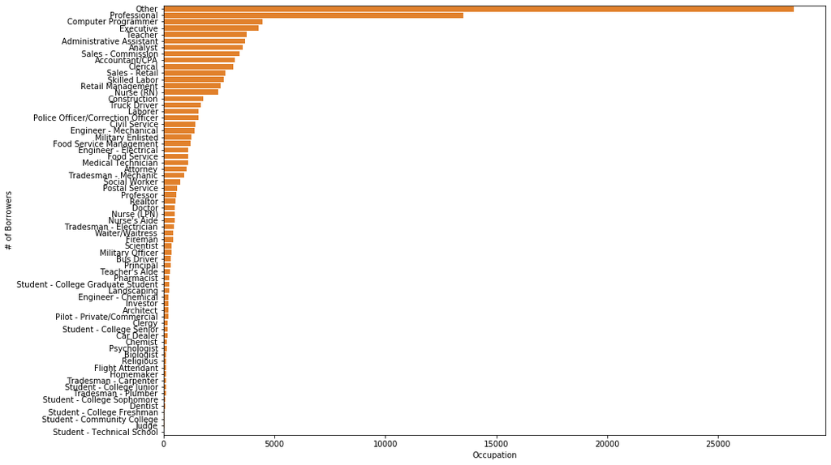

```python
# Plot for Occupation
plt.figure(figsize=[15, 10])

# Order the categorical variable type
cat_order = clean_df['Occupation'].value_counts().index

sb.countplot(data = clean_df, y = 'Occupation', color = default_color, order=cat_order)
plt.xlabel('Occupation')
plt.ylabel('# of Borrowers');
```

Most occupation was described as "Other", which will not provide good insight if this variable will influence loan status

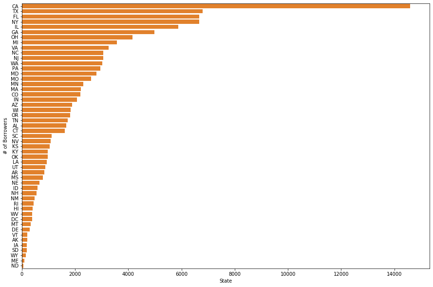

```python
# Plot for State
plt.figure(figsize=[15, 10])

# Order the categorical variable type
cat_order = clean_df['BorrowerState'].value_counts().index

sb.countplot(data = clean_df, y = 'BorrowerState', color = default_color, order=cat_order)
plt.xlabel('State')
plt.ylabel('# of Borrowers');
```

Very interesting that most borrowers are from CA state, while TX, FL, NY, IL, GA are almost in the same range.

## Bivariate Exploration

Now, next step is analysis of correlation between variables

```python
# Numberical vs Categorical features
numeric_vars = ['ProsperRatingN', 'CurrentCreditLines','CreditScoreRangeUpper','LoanOriginalAmount', 'BorrowerAPR','EstimatedReturn']
categoric_vars = ['LoanStatus', 'ListingCategory','Occupation' ,'EmploymentStatus', 'IsBorrowerHomeowner','IncomeRange', 'IncomeVerifiable','BorrowerState']
```

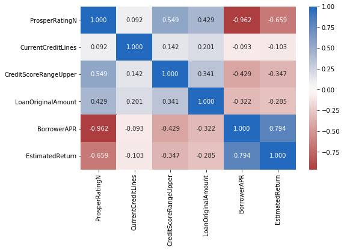

```python
# Correlation plot
plt.figure(figsize = [8, 5])
sb.heatmap(clean_df[numeric_vars].corr(), annot = True, fmt = '.3f',
           cmap = 'vlag_r', center = 0)
plt.show()
```

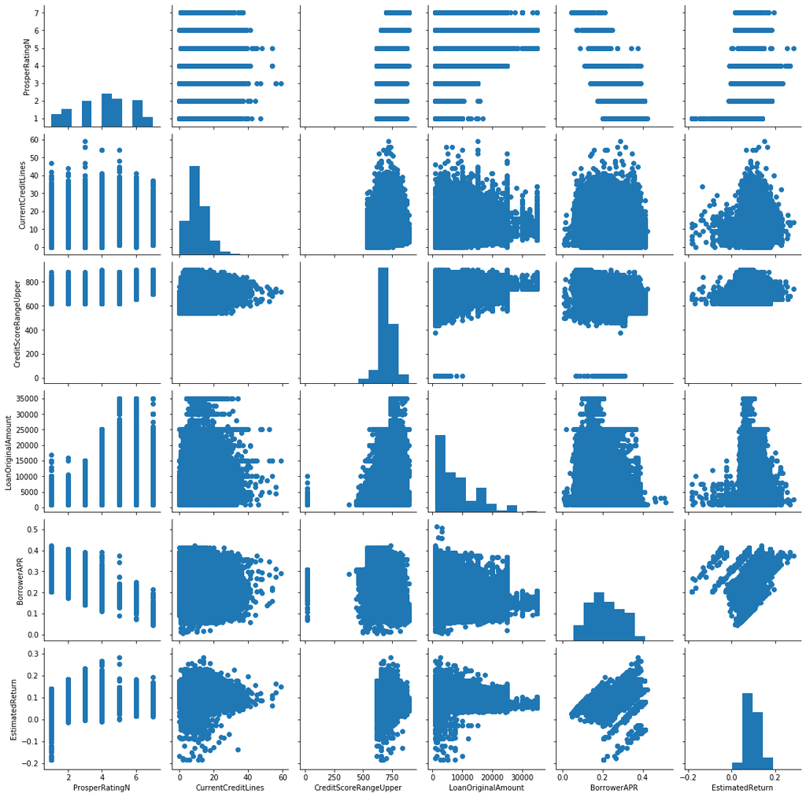

```python
# Plot matrix
g = sb.PairGrid(data = clean_df, vars = numeric_vars)
g = g.map_diag(plt.hist)
g.map_offdiag(plt.scatter);
```

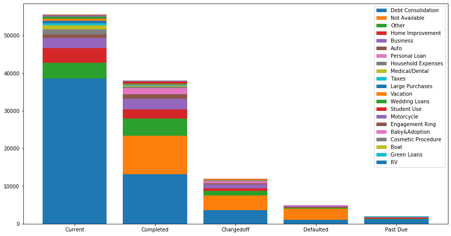

```python
# LoanStatus vs ListingCategory: stacked bar chart
loan_cat_order = ['Current', 'Completed','Chargedoff','Defaulted', 'Past Due']
listing_cat_order = clean_df['ListingCategory'].value_counts().index

baselines = np.zeros(len(loan_cat_order))

plt.figure(figsize = [15, 8])

# for each second-variable category:
for i in range(len(listing_cat_order)):
# isolate the counts of the first category,
    listing_cat = listing_cat_order[i]
    inner_counts = clean_df[clean_df['ListingCategory'] == listing_cat]['LoanStatus'].value_counts()

# then plot those counts on top of the accumulated baseline
    plt.bar(x = np.arange(len(loan_cat_order)), height = inner_counts[loan_cat_order],
            bottom = baselines)
    baselines += inner_counts[loan_cat_order]

plt.xticks(np.arange(len(loan_cat_order)), loan_cat_order)
plt.legend(listing_cat_order);
```

Borrowers whose loan is current chose Debt Consolidation as listing category.

While those loan status are not current, including completed did not indicate listing category.

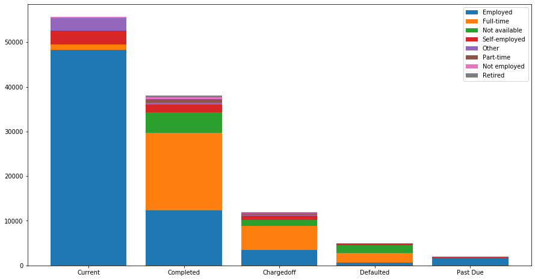

```python
# LoanStatus vs Employment Status: stacked bar chart
loan_cat_order = ['Current', 'Completed','Chargedoff','Defaulted', 'Past Due']
listing_cat_order = clean_df['EmploymentStatus'].value_counts().index

baselines = np.zeros(len(loan_cat_order))

plt.figure(figsize = [15, 8])

# for each second-variable category:
for i in range(len(listing_cat_order)):
# isolate the counts of the first category,
    listing_cat = listing_cat_order[i]
    inner_counts = clean_df[clean_df['EmploymentStatus'] == listing_cat]['LoanStatus'].value_counts()

# then plot those counts on top of the accumulated baseline
    plt.bar(x = np.arange(len(loan_cat_order)), height = inner_counts[loan_cat_order],
            bottom = baselines)
    baselines += inner_counts[loan_cat_order]

plt.xticks(np.arange(len(loan_cat_order)), loan_cat_order)
plt.legend(listing_cat_order);
```

Majority of borrowers are employed and full-time, breaking down by employment status indicates that even those employed and full-time have loan status of defaulty and past-due.

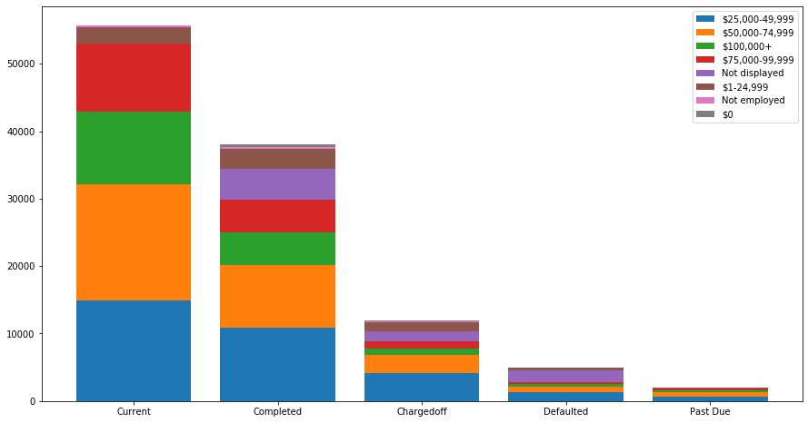

```python
# LoanStatus vs Income Range: stacked bar chart
loan_cat_order = ['Current', 'Completed','Chargedoff','Defaulted', 'Past Due']
listing_cat_order = clean_df['IncomeRange'].value_counts().index

baselines = np.zeros(len(loan_cat_order))

plt.figure(figsize = [15, 8])

# for each second-variable category:
for i in range(len(listing_cat_order)):
# isolate the counts of the first category,
    listing_cat = listing_cat_order[i]
    inner_counts = clean_df[clean_df['IncomeRange'] == listing_cat]['LoanStatus'].value_counts()

# then plot those counts on top of the accumulated baseline
    plt.bar(x = np.arange(len(loan_cat_order)), height = inner_counts[loan_cat_order],
            bottom = baselines)
    baselines += inner_counts[loan_cat_order]

plt.xticks(np.arange(len(loan_cat_order)), loan_cat_order)
plt.legend(listing_cat_order);
```

It is expected that borrwers whose income range fall between 25,000 to 74,999 have loan status of current and completed. But it is also evident that borrowers with income 75,00 and above have loan status current and completed.

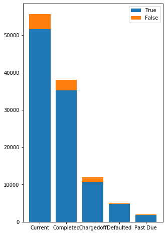

```python
# LoanStatus vs ListingCategory: stacked bar chart
loan_cat_order = ['Current', 'Completed','Chargedoff','Defaulted', 'Past Due']
listing_cat_order = clean_df['IncomeVerifiable'].value_counts().index

baselines = np.zeros(len(loan_cat_order))

plt.figure(figsize = [5, 8])

# for each second-variable category:
for i in range(len(listing_cat_order)):
# isolate the counts of the first category,
    listing_cat = listing_cat_order[i]
    inner_counts = clean_df[clean_df['IncomeVerifiable'] == listing_cat]['LoanStatus'].value_counts()

# then plot those counts on top of the accumulated baseline
    plt.bar(x = np.arange(len(loan_cat_order)), height = inner_counts[loan_cat_order],
            bottom = baselines)
    baselines += inner_counts[loan_cat_order]

plt.xticks(np.arange(len(loan_cat_order)), loan_cat_order)
plt.legend(listing_cat_order);
```

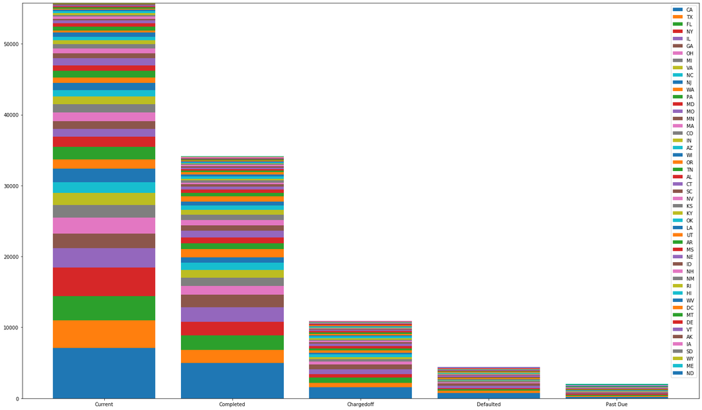

```python
# LoanStatus vs ListingCategory: stacked bar chart
loan_cat_order = ['Current', 'Completed','Chargedoff','Defaulted', 'Past Due']
listing_cat_order = clean_df['BorrowerState'].value_counts().index

baselines = np.zeros(len(loan_cat_order))

plt.figure(figsize = [25, 15])

# for each second-variable category:
for i in range(len(listing_cat_order)):
# isolate the counts of the first category,
    listing_cat = listing_cat_order[i]
    inner_counts = clean_df[clean_df['BorrowerState'] == listing_cat]['LoanStatus'].value_counts()

# then plot those counts on top of the accumulated baseline
    plt.bar(x = np.arange(len(loan_cat_order)), height = inner_counts[loan_cat_order],
            bottom = baselines)
    baselines += inner_counts[loan_cat_order]

plt.xticks(np.arange(len(loan_cat_order)), loan_cat_order)
plt.legend(listing_cat_order);
```

Both variables Income Verifiable and State doesn't provide a determinant factor for status of loan. Majority of borrowers indicated they can provide documentation to verify income regardless of the loan status. While most borrowers are from California, the data for state is distributed among all borrowers.

## Multivariate Exploration

Now, let's consider more than two variables. Look at one categorical variable, Loan Status and four numerical variables such as Loan Amoung, Prosper Rating, Credit Line and Credit Score.

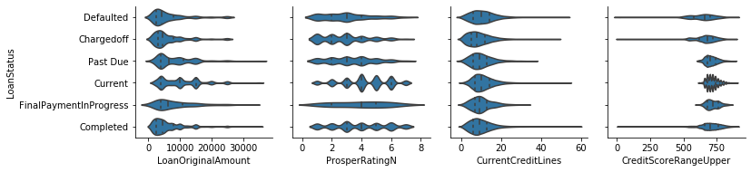

```python
g = sb.PairGrid(data = clean_df, x_vars = ['LoanOriginalAmount','ProsperRatingN', 'CurrentCreditLines','CreditScoreRangeUpper'],
                y_vars = ['LoanStatus'])
g.map(sb.violinplot, inner = 'quartile')
```

As discussed above, in univariate analysis. There is a strong distribution of Current Credit lines between 4 and 14, and a long tail for credit line over 15, this is consistent to all loan status.

The Prosper Rating is distrubuted normally across loan status.

Eventhough the data shows that borrowers with high credit score defaulted or has past due loans, it is evident that the loan status of borrowers with higher credit score are current and completed.

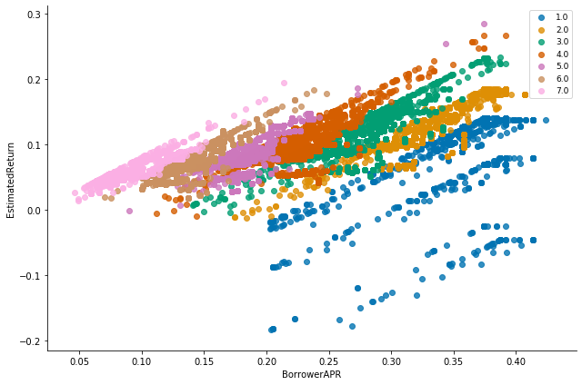

```python
g = sb.FacetGrid(data = clean_df, hue = 'ProsperRatingN',  size = 6, aspect = 1.5, palette="colorblind")
g.map(sb.regplot,"BorrowerAPR", "EstimatedReturn", fit_reg = False);
plt.legend(loc=1, fontsize = 9)
```

## Summary

For this project, I initially did a data assessment and data cleanup. I removed records with duplicate listing keys, to make sure that the borrower's information and loan information are unique. I did a univariate analysis, wherein i plotted each variable that I am interested to analyse. I also did a bivariate analysis to see correlation between two variables, loan status against each categorical variables. Finally, in mulitvariate analysis. I explored one categorical variable, Loan Status and four numerical variables such as Loan Amoung, Prosper Rating, Credit Line and Credit Score.

### Limitations

Although the data provided consist of 81 variables, the project only requires 10 to 15 variables to analyze. There are other variables that can be considered to produec a more meaningful and useful result.